# Daily Electricity Price and Demand Estimation

## Purpose

The main goal of this project is to utilize demand estimation techniques with electricity demand data from a PJM energy consumption data set, https://www.kaggle.com/datasets/robikscube/hourly-energy-consumption.

## Data Cleaning

Data was cleaned separately using R. Each energy utility was merged and totals were calculated for overall hourly energy consumption. 2044 duplicate values were removed.

Data from 2018-08 was removed in R because of a lack of completeness in hourly data. This led to lower monthly totals which skewed the data.

## Packages and Imports

```python
!pip install neuralprophet --quiet
```

```python
import pandas as pd
import numpy as np
import matplotlib.pyplot as plt
plt.rcParams['figure.figsize'] = (15,6)
import itertools
from datetime import timedelta
from sklearn.metrics import mean_squared_error
from datetime import datetime
from statsmodels.tsa.stattools import adfuller
from statsmodels.graphics.tsaplots import plot_pacf
import statsmodels.api as sm
from statsmodels.tsa.statespace.sarimax import SARIMAX

from neuralprophet import NeuralProphet
from neuralprophet import set_random_seed
set_random_seed(0)
```

## Reading in the data

Datetime needs to be specificed using pd.to_datetime to run faster for plots including Datetime.

```python
df = pd.read_csv("energy.csv")

df['Datetime'] = pd.to_datetime(df['Datetime'])
del df['Unnamed: 0'] # deletes unwanted column Unnamed

min(df['Datetime']), max(df['Datetime'])
df = df[['Datetime', 'totals']] # trimming so only deal with totals info
```

[output not shown]

## Let's create daily and montly data from hourly data

This groupy method will group each Datetime, which is currently in hours, to Datetime in days and will sum each utility's load.

```python
len(df['Datetime'].unique()), len(df['Datetime']) # Checks for consistency
df_daily = df.groupby(pd.Grouper(key = 'Datetime', axis = 0, freq='D')).sum().reset_index()
df_monthly = df.groupby(pd.Grouper(key = 'Datetime', axis = 0 ,freq = 'M')).sum().reset_index()
```

## Splitting daily values from years 2013 - 2018 to individual years

```python
format_year = len(df_daily) - 366 # value of 366 was used to capture specific annual dates
df_1718 = df_daily[format_year:]

min(df_1718.Datetime), max(df_1718.Datetime) # this verifies the range of years
```

```
(Timestamp('2017-07-31 00:00:00'), Timestamp('2018-07-31 00:00:00'))
```

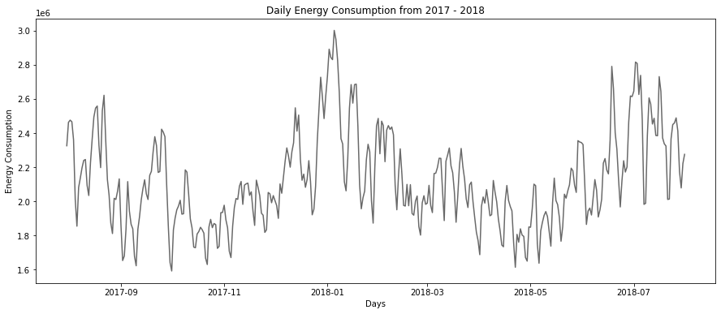

```python
plt.plot(df_1718['Datetime'], df_1718['totals'], color = 'dimgray')
plt.title('Daily Energy Consumption from 2017 - 2018')
plt.xlabel('Days')
plt.ylabel('Energy Consumption')
plt.show()
```

## Decomposing the data to look at seasonality

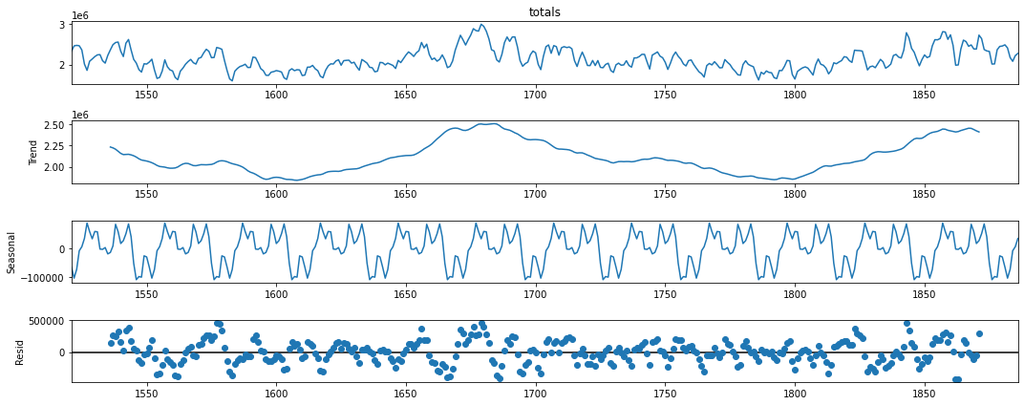

```python
decomposition = sm.tsa.seasonal_decompose(df_1718.totals , model = 'additive', period = 30)
fig = decomposition.plot()
plt.show()
```

## Stationarity Testing

It's obvious that there'a seasonal component to this time series. Nonetheless, here are the dickey-fuller results from testing for stationarity.

Stationarity testing was performed on daily data, subsetted in years. This helps significantly in identifying stationarity.

```python
st_1718 = adfuller(df_1718.totals, regression = 'ct', autolag = 'AIC')
print("P-value: ", st_1718[1])

#pacf = plot_pacf(df.totals, method='ywm', lags = 12)
```

```
P-value:  0.14117427849177377
```

The p-value is greater than 0.05 which implies that autocorrelation is at play here and the data is not stationary. A potential solution to this is first differencing.

```python
df_1718['firstdiff'] = df_1718.totals - df_1718.totals.shift(1)
first_df = df_1718.dropna().reset_index()
first_df = first_df[['Datetime', 'firstdiff']]

st_firstdiff = adfuller(first_df.firstdiff, regression = 'ct', autolag = 'AIC')
print("P-value: ", st_firstdiff[1])
```

[output not shown]

```
P-value:  6.225970310813865e-07
```

After performing a first-difference, the p-value vastly improves and the data is now consistent.

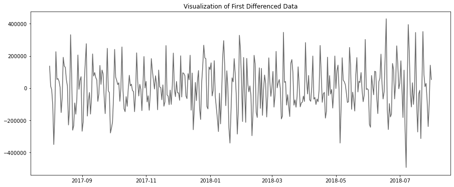

```python
plt.plot(first_df.Datetime, first_df.firstdiff, color = 'dimgray')
plt.title('Visualization of First Differenced Data')
```

## SARIMAX

[output not shown]

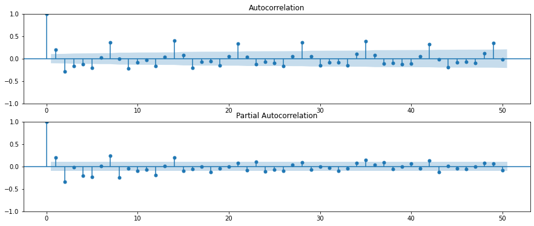

```python
fig, ax = plt.subplots(2,1)
fig = sm.graphics.tsa.plot_acf(first_df.firstdiff, lags = 50, ax = ax[0])
fig = sm.graphics.tsa.plot_pacf(first_df.firstdiff, lags = 50, ax = ax[1])
plt.show()
```

```python
best_model = SARIMAX(first_df.firstdiff, order = (2, 1, 2), seasonal_order = (2, 1, 2, 12)).fit(dis=-1)
print(best_model.summary())
```

[output not shown]

[output not shown]

[output cut: 18 more lines]

```
ar.S.L12      -1.0502      0.296     -3.549      0.000      -1.630      -0.470
ar.S.L24      -0.2157      0.165     -1.308      0.191      -0.539       0.108
ma.S.L12       0.0227      0.312      0.073      0.942      -0.589       0.634
ma.S.L24      -0.7686      0.322     -2.387      0.017      -1.400      -0.138
sigma2      4.652e+10   4.57e-12   1.02e+22      0.000    4.65e+10    4.65e+10
===================================================================================
Ljung-Box (L1) (Q):                   0.00   Jarque-Bera (JB):                 0.78
Prob(Q):                              0.97   Prob(JB):                         0.68
Heteroskedasticity (H):               1.31   Skew:                             0.09
Prob(H) (two-sided):                  0.15   Kurtosis:                         3.13
===================================================================================

Warnings:
[1] Covariance matrix calculated using the outer product of gradients (complex-step).
[2] Covariance matrix is singular or near-singular, with condition number 9.06e+38. Standard errors may be unstable.
```

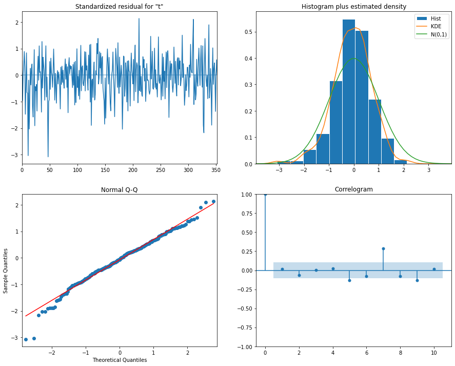

```python
best_model.plot_diagnostics(figsize=(15,12));
```